# step 4 visualize results

Zachary Amir

2024-11-18 08:13:12

## Introduction

This Rmarkdown file will be used to generate all key plots included in the main and supplementary text of our manuscript. Additional plots will likely be generated as well, but only the key plots will be visualized in this document.

## Histograms

Histograms are a key tool for visualizing the results from many co-abundance models, by examining the count of different species interaction values (SIV) from different levels of support. Below you will see the key plots generated in this document, following the support criteria defined in step 3. Note that additional plots with more conservative PPC settings (matching those of Amir et al 2022, Ecology & Evolution) will be saved to dropbox but not visualized in this document.

The first plot visualized the conceptual outcome of our hypotheses. If our top-down hypothesis is supported, then the majority of SIVs would be significant and negative. If our bottom-up hypothesis is supported, then the majority of SIVs would be significant and positive.

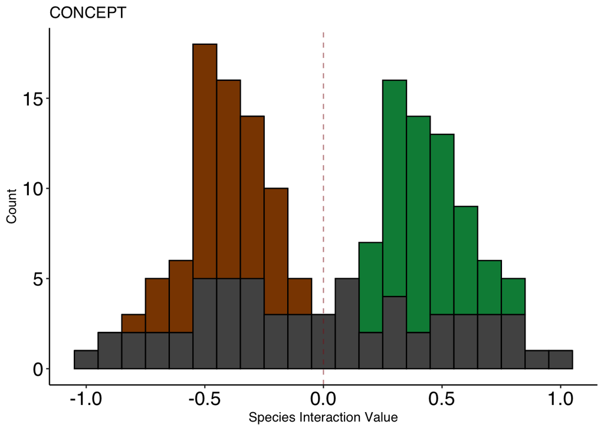

The next plot is the pooled results from **preferred predator prey models** where all models are combined into a single histogram. The supported top-down results include 2 models, which is 3 percent of the available models. The supported bottom-up results include 15 models, which is 22.7 percent of the available models. Finally, the unsupported results include 49 models, which is 74.2 percent of the available models.

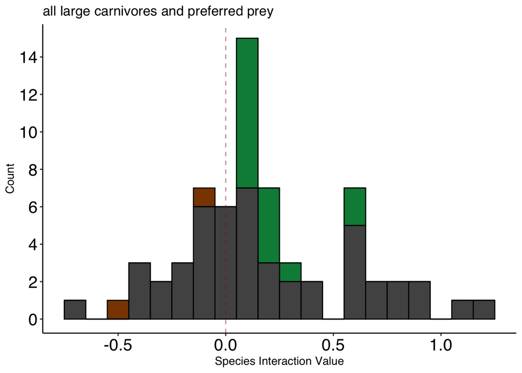

- The results for Panthera_tigris include 1 supported top-down models (5.6%), 2 supported bottom-up models (11.1%), and 15 unsupported models (83.3%).
- The results for Panthera_pardus include 1 supported top-down models (7.1%), 2 supported bottom-up models (14.3%), and 11 unsupported models (78.6%).
- The results for Cuon_alpinus include supported top-down models (%), 3 supported bottom-up models (30%), and 7 unsupported models (70%).
- The results for Neofelis_genus include supported top-down models (%), 8 supported bottom-up models (33.3%), and 16 unsupported models (66.7%).

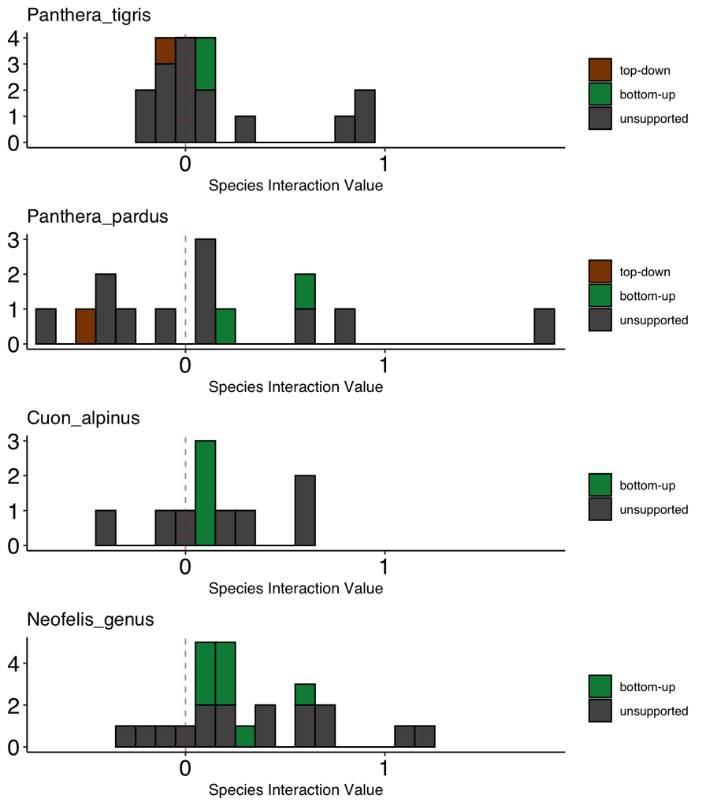

The next plot is the pooled results from **all predator prey models across the community** where all models are combined into a single histogram. The supported top-down results include 9 models, which is 3.5 percent of the available models. The supported bottom-up results include 36 models, which is 13.8 percent of the available models. Finally, the unsupported results include 215 models, which is 82.7 percent of the available models.

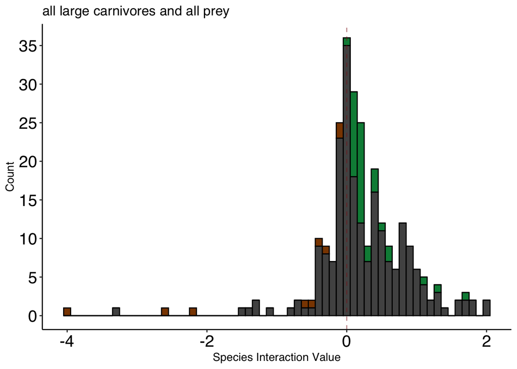

The next plot includes all predator prey models across the community (same as above), but this time split between the four large carnivore species.

- The results for Panthera_tigris include 5 supported top-down models (7.6%), 4 supported bottom-up models (6.1%), and 57 unsupported models (86.4%).
- The results for Panthera_pardus include 2 supported top-down models (3.7%), 6 supported bottom-up models (11.1%), and 46 unsupported models (85.2%).
- The results for Cuon_alpinus include 2 supported top-down models (3.1%), 10 supported bottom-up models (15.4%), and 53 unsupported models (81.5%).
- The results for Neofelis_genus include supported top-down models (%), 16 supported bottom-up models (21.3%), and 59 unsupported models (78.7%).

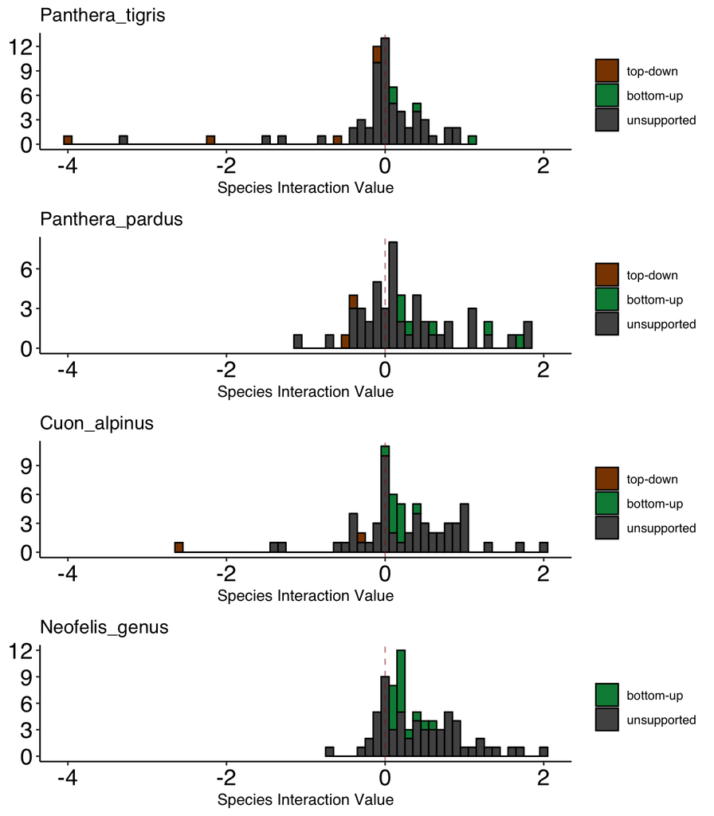

- The top-down results for Panthera_tigris include 3 unsupported_1 models (37.5%), 2 unsupported_2 models (25%), and 3 unsupported_3 models (37.5%).
- The top-down results for Panthera_pardus include 2 unsupported_1 models (33.33%), 4 unsupported_2 models (66.67%), and unsupported_3 models (%).
- The top-down results for Cuon_alpinus include 1 unsupported_1 models (20%), unsupported_2 models (%), and 4 unsupported_3 models (80%).
- The results for Neofelis_genus include 3 unsupported_1 models (25%), 1 unsupported_2 models (8.33%), and 8 unsupported_3 models (66.67%).

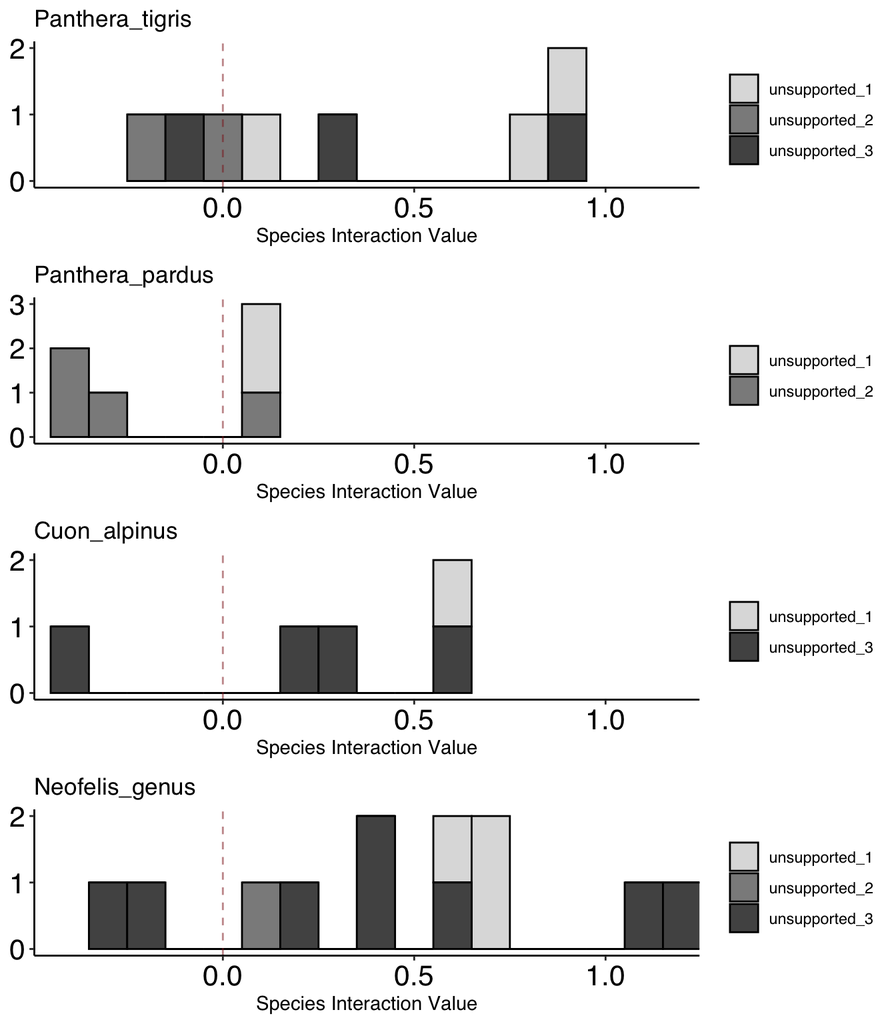

- The bottom-up results for Panthera_tigris include unsupported_1 models (%), 6 unsupported_2 models (85.71%), and 1 unsupported_3 models (14.29%).
- The bottom-up results for Panthera_pardus include unsupported_1 models (%), 1 unsupported_2 models (20%), and 4 unsupported_3 models (80%).
- The bottom-up results for Cuon_alpinus include unsupported_1 models (%), 2 unsupported_2 models (100%), and unsupported_3 models (%).
- The results for Neofelis_genus include 1 unsupported_1 models (25%), 2 unsupported_2 models (50%), and 1 unsupported_3 models (25%).

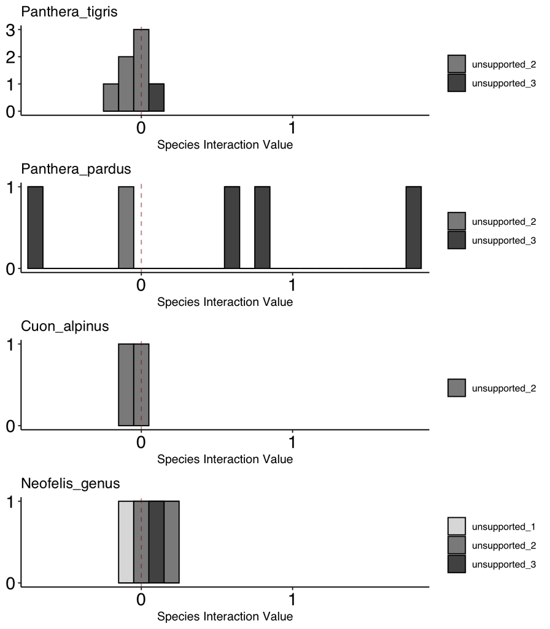

## Counter-factual histograms

Below is a graph of the SIVs from 5 counter-factual tests, and compared with the original results presented above. As a reminder, all counter-factual tests only include preferred predator-prey co-abundance models.

- For the counter-factual test original_test, there were 2 supported top-down models (3%), 15 supported bottom-up models (22.7%), and 49 unsupported models (74.2%).
- For the counter-factual test site_matching, there were 1 supported top-down models (2.5%), 11 supported bottom-up models (27.5%), and 28 unsupported models (70%).
- For the counter-factual test isolate_extirpations, there were 2 supported top-down models (3%), 16 supported bottom-up models (24.2%), and 48 unsupported models (72.7%).
- For the counter-factual test isolate_altitude, there were 2 supported top-down models (3.1%), 12 supported bottom-up models (18.5%), and 51 unsupported models (78.5%).
- For the counter-factual test isolate_FLII, there were 2 supported top-down models (3.2%), 13 supported bottom-up models (20.6%), and 48 unsupported models (76.2%).
- For the counter-factual test isolate_HFP, there were 2 supported top-down models (3.1%), 13 supported bottom-up models (20%), and 50 unsupported models (76.9%).

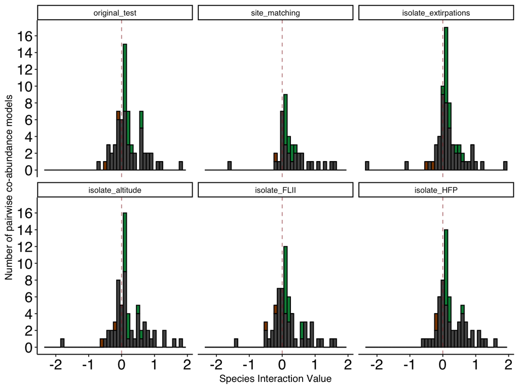

## Save plots & data

The plots, and data used to inform this document, will be saved in dropbox at this directory: Dropbox/Zach PhD/Ch3 Trophic release project/SEA_TC_GitHub_data_storage/figures/step4_output_figs/ & figures/step4_output_summarized_results_for_figs